# Mummichog Report: data_pos_both_before_blank_subtraction

mummichog version: 2.2.0-20200207, using metabolic model MFN_1.10.4.

## User input data

User supplied 6236 features as reference list.We are using 1733 features (p < 0.050000) as significant list. The feature level data are shown in the Manhattan plots below.

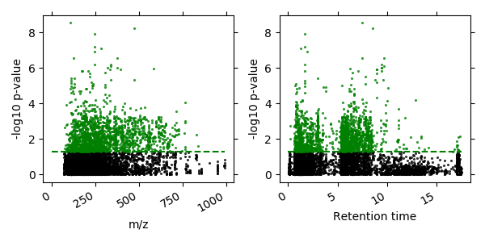

## Top pathways

The reference feature list is mapped to 661 EmpiricalCompounds, significant features to 226 EmpiricalCompounds. In the table below, pathway_size is number of detected EmpiricalCompounds for each pathway; overlap_size is number of significant EmpiricalCompounds. Empirical p-values are estimated by permutation test. Details on EmpiricalCompounds are in 'tables/ListOfEmpiricalCompounds.tsv'.

[output not shown]

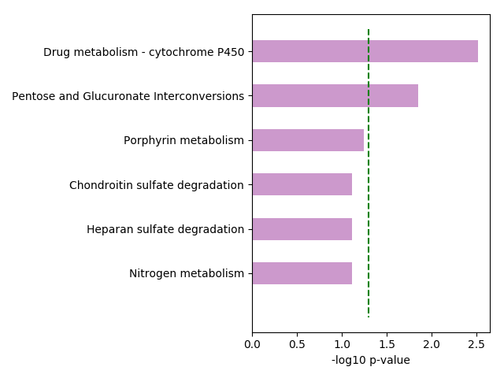

## EmpiricalCompounds favored by above analyses

An EmpiricalCompound is a computational unit for a tentative metabolite. It can group multiple ions, and be any of the isobaric/isomeric species. This table contains EmpiricalCompounds prioritized by pathway/module analysis.

| EmpiricalCompound | Input m/z | Retention time | ion | mz_diff | Statistic | Significant |
| --- | --- | --- | --- | --- | --- | --- |
| E647 | Best guess: C07572, Citalopram |  | C07572 |  |  |  |
|  | 325.170857236 | 5.32034102564 | M+H[1+] | -0.0002 | -2.66 | yes |
|  | 325.170765168 | 5.26382307692 | M+H[1+] | -0.0003 | -2.74 | yes |
| E229 | Best guess: C16560, 3-Hydroxylidocaine |  | C16560 |  |  |  |
|  | 273.155818632 | 1.50120729167 | M+Na[1+] | -0.0016 | -2.9 | yes |
| E666 | Best guess: C16550, Dechloroethylcyclophosphamide |  | C16550 |  |  |  |
|  | 100.023833946 | 1.88126363636 | M+2H[2+] | 0.0003 | 0.82 | no |
|  | 200.041260719 | 1.54119166667 | M(C13)+H[1+] | -0.0019 | 2.56 | yes |
|  | 100.023852837 | 2.10191439394 | M+2H[2+] | 0.0003 | 0.71 | no |
|  | 221.022871593 | 1.51344895833 | M+Na[1+] | 0.0011 | -0.17 | no |
| E718 | Best guess: C00191, D-Glucuronate |  | C00618, C06472, C00191 |  |  |  |
|  | 196.0522875 | 1.12380208333 | M(C13)+H[1+] | -0.0011 | -0.13 | no |
|  | 195.05178247 | 1.015534375 | M+H[1+] | 0.0018 | 3.21 | yes |
| E995 | Best guess: C16587, 3-Carbamoyl-2-phenylpropionaldehyde |  | C16595, C16587 |  |  |  |
|  | 216.063360444 | 0.792421568627 | M+Na[1+] | 0.0002 | -5.2 | yes |
| E398 | Best guess: C00191, D-Glucuronate |  | C00618, C06472, C00191 |  |  |  |
|  | 217.031463294 | 2.0662254902 | M+Na[1+] | -0.0005 | -2.99 | yes |
| E523 | Best guess: C07501, Felbamate |  | C07501 |  |  |  |
|  | 239.100457973 | 2.9515030303 | M+H[1+] | -0.0022 | -3.62 | yes |
| E1488 | Best guess: C16582, 2-Hydroxyfelbamate |  | C16584, C16582 |  |  |  |
|  | 255.097476578 | 1.52667395833 | M+H[1+] | -0.0001 | -4.53 | yes |
| E801 | Best guess: C07501, Felbamate |  | C07501 |  |  |  |
|  | 239.102697112 | 5.476959375 | M+H[1+] | 0.0 | -3.94 | yes |
|  | 239.10250297 | 5.60432708333 | M+H[1+] | -0.0002 | -1.8 | no |
|  | 239.101718052 | 5.39124230769 | M+H[1+] | -0.001 | 0.36 | no |
| E169 | Best guess: C16582, 2-Hydroxyfelbamate |  | C16584, C16582 |  |  |  |
|  | 255.097340422 | 1.94955909091 | M+H[1+] | -0.0002 | 3.37 | yes |
| E1155 | Best guess: C00121, D-Ribose |  | C00310, C00312, C00181, C00259, C00309, C00121 |  |  |  |
|  | 173.042361688 | 0.913500793651 | M+Na[1+] | 0.0003 | 4.35 | yes |
|  | 173.042610519 | 1.30252105263 | M+Na[1+] | 0.0005 | 2.32 | yes |
|  | 150.053441171 | 1.5127969697 | M[1+] | 0.0006 | -2.04 | no |
|  | 152.062866718 | 1.5109254386 | M(C13)+H[1+] | -0.0006 | -0.83 | no |
|  | 173.042836328 | 1.00689166667 | M+Na[1+] | 0.0008 | -0.39 | no |
| E744 | Best guess: C16596, 5-Phenyl-1,3-oxazinane-2,4-dione |  | C05635, C16596 |  |  |  |
|  | 192.065716295 | 6.97164509804 | M+H[1+] | 0.0002 | -3.25 | yes |
| E19 | Best guess: CE5276, dopamine o-quinone |  | C00532, C00379, CE5276 |  |  |  |
|  | 153.077250394 | 17.1758181818 | M+H[1+] | -0.0012 | -2.27 | yes |
| E298 | Best guess: C00121, D-Ribose |  | C00310, C00508, CE5277, C00312, C00181, C00259, C00309, C00121 |  |  |  |
|  | 173.043100917 | 2.96515416667 | M+Na[1+] | 0.001 | -4.43 | yes |
| E49 | Best guess: C16582, 2-Hydroxyfelbamate |  | C16584, C16582 |  |  |  |
|  | 255.09552887 | 2.95324333333 | M+H[1+] | -0.002 | -3.75 | yes |
| E560 | Best guess: C16561, Monoethylglycinexylidide |  | C16561 |  |  |  |
|  | 229.129388438 | 2.233384375 | M+Na[1+] | -0.0018 | -1.42 | no |
|  | 229.129374631 | 2.14833333333 | M+Na[1+] | -0.0018 | 2.17 | yes |

## More data

Full data tables from pathway analysis, module analysis and activity network are stored in the 'tables/' directory. The tsv files can be imported into a spreadsheet program, e.g. MS Excel. Under the 'figures/network_modules/' directory are files intended for Cytoscape (cytoscape.org) visualization. Please refer to Cytoscape's guides for details. Details of this run are recorded in file mummichog.log.txt.